# Sample Test Summary

# Testing 70/30 splits

For the two best-performing models in Phase II, we additionally investigated alternative methods of sampling the training and test data. In Phase II, training and test data were developed by randomly splitting all grid x hour combinations 70/30, meaning, 30% of the data from April-September was withheld from the model fitting. This 30% of the data was then fed into the model, and the observed EDT crashes were compared with the estimated EDT crashes.

For this test, rather than take a 70/30 split of all data by grid and hour, 70/30 splits by whole days or by whole weeks was developed. If there are important patterns which separate one whole day from another day, or separate whole weeks, such splits may better capture the structure of the data.

## Model 23

Model 23 included all Waze events, but not direction of travel (magvar), alert reliability or confidence, or number of crashes or jams from neighboring cells. This model also included all auxiliary data, including weather, miles of road by functional class, AADT, historical FARS crashes, and jobs data.

By AUC, these models were all within a rounding error in performance. Recall was highest when sampling by day, at the expense of precision and false positive rate.

```r
load(file.path(localdir, "Output_to_30_week"))

tabl <- vector()
mods = names(keyoutputs)[1:3]
for(i in mods){ tabl <- rbind(tabl, c(100*keyoutputs[[i]]$diag, round(keyoutputs[[i]]$auc, 4)))}

colnames(tabl)[1:5] = c("Accuracy", "Precision", "Recall", "False Positive Rate", "AUC")
rownames(tabl) = mods
datatable(tabl, filter = 'top',
          caption = "Testing 70/30 sampling by day and week for Model 23.",
          rownames = T,
          options = list(dom = "t",
                         pageLength = length(mods))
          ) %>% formatCurrency(2:4, currency = "", digits = 2) %>%
          formatStyle(1, background = styleEqual(max(tabl[,1]), 'lightgreen'))%>%
          formatStyle(2, background = styleEqual(max(tabl[,2]), 'lightgreen'))%>%
          formatStyle(3, background = styleEqual(max(tabl[,3]), 'lightgreen'))%>%
          formatStyle(4, background = styleEqual(min(tabl[,4]), 'lightgreen'))%>%
          formatStyle(5, background = styleEqual(max(tabl[,5]), 'lightgreen'))
```

|  | Accuracy | Precision | Recall | False Positive Rate | AUC |
| --- | --- | --- | --- | --- | --- |
| 23_original | 98.43 | 54.74 | 59.85 | 0.88 | 0.9896 |
| 23_day | 98.33 | 54.32 | 60.28 | 0.95 | 0.9888 |
| 23_week | 98.41 | 56.49 | 58.11 | 0.84 | 0.9897 |

Variable importance followed the same pattern for the four most important predictors in each, with some variation in the order of the next several predictors. The top 15 of 58 predictors are shown in the following figure:

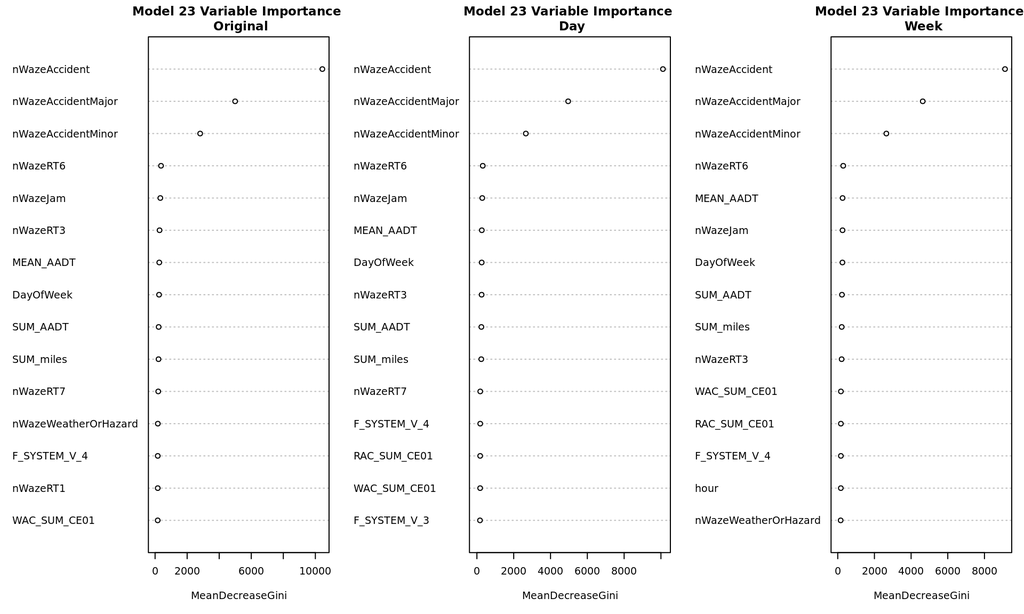

```r
s3load(object = file.path(outputdir, paste("Model_23_original_RandomForest_Output.RData", sep= "_")), bucket = waze.bucket)
rf.out.og <- rf.out

s3load(object = file.path(outputdir, paste("Model_23_day_RandomForest_Output.RData", sep= "_")), bucket = waze.bucket)
rf.out.day <- rf.out

s3load(object = file.path(outputdir, paste("Model_23_week_RandomForest_Output.RData", sep= "_")), bucket = waze.bucket)
rf.out.week <- rf.out

par(mfrow=c(1,3), mar = c(5,3, 3, 1))
varImpPlot(rf.out.og,
           main = "Model 23 Variable Importance \n Original",
           n.var = 15,
           cex = 0.6)
varImpPlot(rf.out.day,
           main = "Model 23 Variable Importance \n Day",
           n.var = 15,
           cex = 0.6)
varImpPlot(rf.out.week,
           main = "Model 23 Variable Importance \n Week",
           n.var = 15,
           cex = 0.6)
```

## Model 30

Model 30 included all Waze alert types, but not subtypes, and included direction of travel (magvar), alert reliability or confidence, and number of crashes or jams from neighboring cells. This model also included all auxiliary data, including weather, miles of road by functional class, AADT, historical FARS crashes, and jobs data.

Recall and the best balance between false positives and false negatives (AUC) were highest for the original sampling, but all three models were very similar. Greater precision and lower false positive rate were accomplished in the sampling by week.

```r
load(file.path(localdir, "Output_to_30_week"))

tabl <- vector()
mods = names(keyoutputs)[4:6]
for(i in mods){ tabl <- rbind(tabl, c(100*keyoutputs[[i]]$diag, round(keyoutputs[[i]]$auc, 4)))}

colnames(tabl)[1:5] = c("Accuracy", "Precision", "Recall", "False Positive Rate", "AUC")
rownames(tabl) = mods
datatable(tabl, filter = 'top',
          caption = "Testing 70/30 sampling by day and week for Model 30.",
          rownames = T,
          options = list(dom = "t",
                         pageLength = length(mods))
          ) %>% formatCurrency(2:4, currency = "", digits = 2) %>%
          formatStyle(1, background = styleEqual(max(tabl[,1]), 'lightgreen'))%>%
          formatStyle(2, background = styleEqual(max(tabl[,2]), 'lightgreen'))%>%
          formatStyle(3, background = styleEqual(max(tabl[,3]), 'lightgreen'))%>%
          formatStyle(4, background = styleEqual(min(tabl[,4]), 'lightgreen'))%>%
          formatStyle(5, background = styleEqual(max(tabl[,5]), 'lightgreen'))
```

|  | Accuracy | Precision | Recall | False Positive Rate | AUC |
| --- | --- | --- | --- | --- | --- |
| 30_original | 98.45 | 55.58 | 58.24 | 0.83 | 0.9908 |
| 30_day | 98.47 | 52.78 | 57.1 | 0.84 | 0.9905 |
| 30_week | 98.43 | 58.71 | 55.24 | 0.74 | 0.9908 |

As for Model 23, Variable importance followed the same pattern for the four most important predictors in each. Waze Road Type 6, Primary Roads, was consistently important in both models. The top 15 of 62 predictors are shown in the following figure:

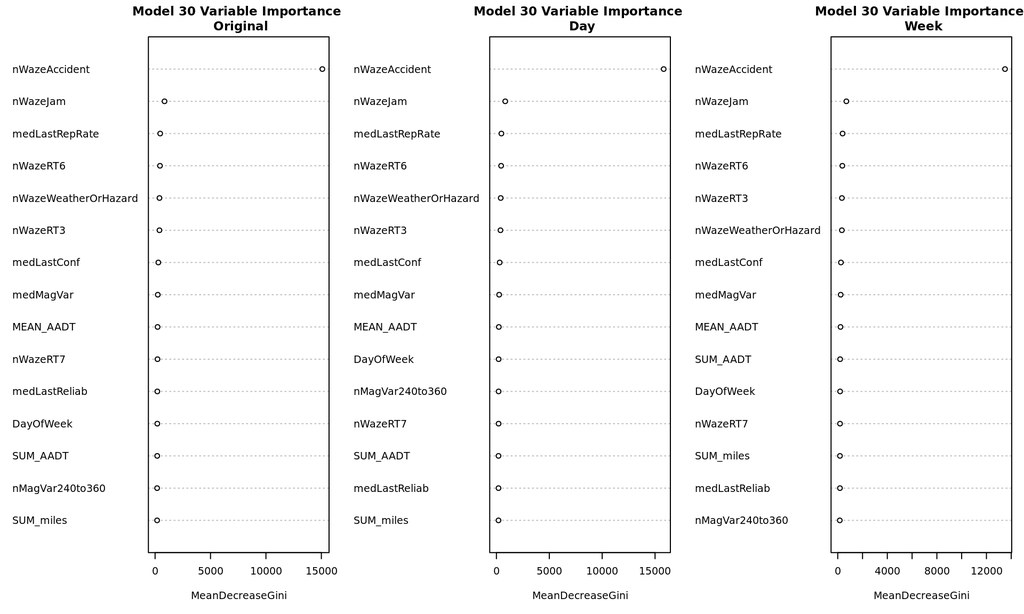

```r
s3load(object = file.path(outputdir, paste("Model_30_original_RandomForest_Output.RData", sep= "_")), bucket = waze.bucket)
rf.out.og <- rf.out

s3load(object = file.path(outputdir, paste("Model_30_day_RandomForest_Output.RData", sep= "_")), bucket = waze.bucket)
rf.out.day <- rf.out

s3load(object = file.path(outputdir, paste("Model_30_week_RandomForest_Output.RData", sep= "_")), bucket = waze.bucket)
rf.out.week <- rf.out

par(mfrow=c(1,3), mar = c(5,3, 3, 1))
varImpPlot(rf.out.og,
           main = "Model 30 Variable Importance \n Original",
           n.var = 15,
           cex = 0.6)
varImpPlot(rf.out.day,
           main = "Model 30 Variable Importance \n Day",
           n.var = 15,
           cex = 0.6)
varImpPlot(rf.out.week,
           main = "Model 30 Variable Importance \n Week",
           n.var = 15,
           cex = 0.6)
```